# Self-Driving Car Engineer Nanodegree

## Project: Build a Traffic Sign Recognition Classifier

In this notebook, a template is provided for you to implement your functionality in stages, which is required to successfully complete this project. If additional code is required that cannot be included in the notebook, be sure that the Python code is successfully imported and included in your submission if necessary.

In addition to implementing code, there is a writeup to complete. The writeup should be completed in a separate file, which can be either a markdown file or a pdf document. There is a [write up template](https://github.com/udacity/CarND-Traffic-Sign-Classifier-Project/blob/master/writeup_template.md) that can be used to guide the writing process. Completing the code template and writeup template will cover all of the [rubric points](https://review.udacity.com/#!/rubrics/481/view) for this project.

The [rubric](https://review.udacity.com/#!/rubrics/481/view) contains "Stand Out Suggestions" for enhancing the project beyond the minimum requirements. The stand out suggestions are optional. If you decide to pursue the "stand out suggestions", you can include the code in this Ipython notebook and also discuss the results in the writeup file.

> **Note:** Code and Markdown cells can be executed using the **Shift + Enter** keyboard shortcut. In addition, Markdown cells can be edited by typically double-clicking the cell to enter edit mode.

## Step 0: Load The Data

### First, import the library that we need

```python
import numpy as np
import tensorflow as tf
import matplotlib.pyplot as plt
import os
from scipy import ndimage
from skimage.transform import resize
from skimage.data import imread
from skimage import color
import pickle
```

### Here I use a class called data to manage the dataset

- First, I load the train, val, test data by function `load_data()`
- Then check the number of the data and label
- normalize the grayscale the images by function `normal_grayscale()` (Here I use the skimage to do the image process)
- Augment training data by using function `expend_training_data()`
- I wirte a function called `next_batch()` to feed random minibatch to the model

```python
class data(object):
    def __init__(self, training_file, validation_file, testing_file):
        self.train_x, self.train_y = self.load_data(training_file)
        self.val_x, self.val_y = self.load_data(validation_file)
        self.test_x, self.test_y = self.load_data(testing_file)
        # check the num of data and label
        self.check_data()

        self.normal_grayscale()

        self.img_shape = self.train_x[0].shape
        self.n_classes = np.max(self.train_y) + 1

        self.expend_training_data()

        self.n_train = self.train_x.shape[0]
        self.n_val = self.val_x.shape[0]
        self.n_test = self.test_x.shape[0]

    def check_data(self):
        assert (len(self.train_x) == len(self.train_y))
        assert (len(self.val_x) == len(self.val_y))
        assert (len(self.test_x) == len(self.test_y))

    def print_data_info(self):
        print("Number of training examples =", self.n_train)
        print("Number of validation examples =", self.n_val)
        print("Number of testing examples =", self.n_test)
        print("Image data shape =", self.img_shape)
        print("Number of classes =", self.n_classes)

    def load_data(self, path):
        with open(path, mode='rb') as f:
            tmp = pickle.load(f)
        return tmp['features'], tmp['labels']

    def normal_grayscale(self):
        self.train_x = (self.train_x - 128.) / 128.
        self.val_x = (self.val_x - 128.) / 128.
        self.test_x = (self.test_x - 128.) / 128.

        # convert rgb to gray scale
        self.train_x = color.rgb2gray(self.train_x)
        self.val_x = color.rgb2gray(self.val_x)
        self.test_x = color.rgb2gray(self.test_x)

    def next_batch(self, batch_size):
        """
        Return a total of `num` random samples and labels.
        """
        idx = np.arange(0, len(self.train_x))
        np.random.shuffle(idx)
        idx = idx[:batch_size]
        data_shuffle = [self.train_x[i] for i in idx]
        labels_shuffle = [self.train_y[i] for i in idx]

        return np.asarray(data_shuffle), np.asarray(labels_shuffle)


    def expend_training_data(self):
        """
        Augment training data
        """
        expanded_images = np.zeros([self.train_x.shape[0] * 5, self.img_shape[0], self.img_shape[1]])
        expanded_labels = np.zeros([self.train_x.shape[0] * 5])

        counter = 0
        for x, y in zip(self.train_x, self.train_y):

            # register original data
            expanded_images[counter, :, :] = x
            expanded_labels[counter] = y
            counter = counter + 1

            # get a value for the background
            # zero is the expected value, but median() is used to estimate background's value
            bg_value = np.median(x)  # this is regarded as background's value

            for i in range(4):
                # rotate the image with random degree
                angle = np.random.randint(-15, 15, 1)
                new_img = ndimage.rotate(x, angle, reshape=False, cval=bg_value)

                # shift the image with random distance
                shift = np.random.randint(-2, 2, 2)
                new_img_ = ndimage.shift(new_img, shift, cval=bg_value)

                # register new training data
                expanded_images[counter, :, :] = new_img_
                expanded_labels[counter] = y
                counter = counter + 1

        self.train_x = expanded_images
        self.train_y = expanded_labels
```

### Load data and print a basic summary of the dataset

The dataset is put into a folder called data/

```python
training_file = 'data/train.p'
validation_file = 'data/valid.p'
testing_file = 'data/test.p'

is_debug = True

data = data(training_file, validation_file, testing_file)
data.print_data_info()
```

```
Number of training examples = 173995
Number of validation examples = 4410
Number of testing examples = 12630
Image data shape = (32, 32)
Number of classes = 43
```

### According to the info we know that there is 43 classes of sign. After data augmentation, the number of training sample become 173995. Next I write a plot function to show the images from the dataset

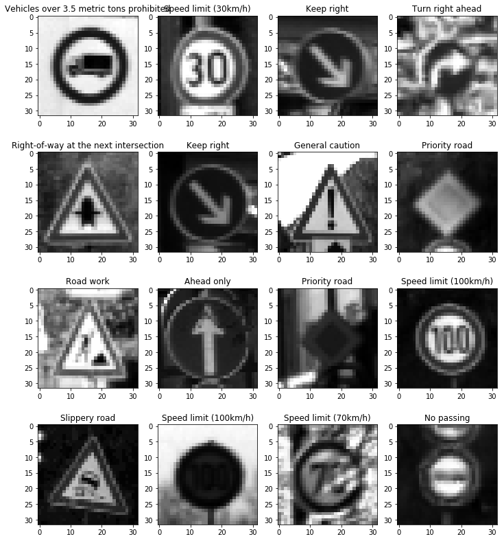

```python
# use a dictionary to manage the key-label
label_dict = {}
with open('signnames.csv', 'r') as f:
    lines = f.readlines()
    for line in lines[1:]:
        tmp = line.strip('\n')
        tmp = tmp.split(',')
        label_dict[tmp[0]] = tmp[1]
    f.close()


def subplot_show(img_list, label_list, gray=False):
    """
    show 16 pictures
    the img_list must be a list with 16 images
    """
    plt.figure(figsize=(12, 14))
    for i in range(len(img_list)):
        plt.subplot(4, 4, i + 1)
        plt.title(label_dict[str(int(label_list[i]))])
        if gray is True:
            plt.imshow(img_list[i], cmap='gray')
        else:
            plt.imshow(img_list[i])
    plt.show()

# # the original images
# subplot_show(data.test_x[:4])

# image after normalization and convert to gray scale
if is_debug:
    subplot_show(data.test_x[:16], data.test_y[:16], gray=True)
```

### Show some images of training dataset, here we can see the result of data augmentation

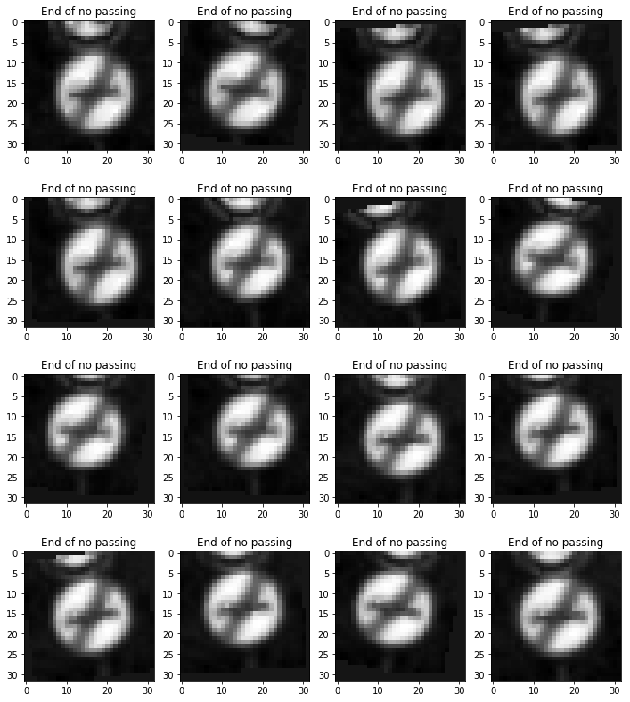

```python
if is_debug:
    subplot_show(data.train_x[:16], data.train_y[:16], gray=True)
```

## Step 2: Design and Test a Model Architecture

### In this stage, I write a class called LeNet. I have not change the structure of the LeNet model. The kernal size, input size, output size, hidden neurons are all the same with lectures. I add the following code:

- First, I used the namespace and variable space to manage the paramenters instead of the dictionary
- I write some helper function like `conv2d()`, `maxpool2d()` and `fc_layer()`
- I write some information to summary so we can use **tensorboard** to visualize
- The model is saved to a checkpoint file by using saver
- Here I use the Adam Optimizer to train the model
- the learning rate is 0.001

```python
class LeNet(object):
    def __init__(self, data, lr=0.001):

        self.x_placeholder = tf.placeholder(tf.float32, shape=[None, data.img_shape[0], data.img_shape[1]],
                                           name='input_x')
        tf.add_to_collection('x_placeholder', self.x_placeholder)
        self.y_placeholder = tf.placeholder(tf.int32, shape=[None], name='input_y')
        tf.add_to_collection('y_placeholder', self.y_placeholder)
        self.keep_p = tf.placeholder(tf.float32)

        input = tf.reshape(self.x_placeholder, (-1, data.img_shape[0], data.img_shape[1], 1))

        one_hot = tf.one_hot(self.y_placeholder, depth=data.n_classes)
        one_hot = tf.reshape(one_hot, (-1, data.n_classes))

        self.conv1 = self.conv2d(input, 'conv1', 5, 5, 1, 6)
        self.maxpool1 = self.maxpool2d(self.conv1, 'max_pool1')

        self.conv2 = self.conv2d(self.maxpool1, 'conv2', 5, 5, 6, 16)
        self.maxpool2 = self.maxpool2d(self.conv2, 'max_pool2')

        fc1 = tf.reshape(self.maxpool2, [-1, 5 * 5 * 16])
        fc1 = self.fc_layer(fc1, 'fc1', 5 * 5 * 16, 120, relu=True)
        # add dropout layer
        fc1_dropout = tf.nn.dropout(fc1, keep_prob=self.keep_p)

        fc2 = self.fc_layer(fc1_dropout, 'fc2', 120, 84, relu=True)
        fc2_dropout = tf.nn.dropout(fc2, keep_prob=self.keep_p)

        self.output = self.fc_layer(fc2_dropout, 'out', 84, data.n_classes, relu=False)

        with tf.name_scope('global_operation'):
            self.global_step = tf.Variable(0, trainable=False)

            softmax = tf.nn.softmax(self.output, name='softmax')
            self.top_k = tf.nn.top_k(softmax, k=5)

            self.loss = tf.reduce_mean(tf.nn.softmax_cross_entropy_with_logits(labels=one_hot, logits=self.output))
            tf.add_to_collection('loss', self.loss)
            tf.summary.scalar('loss', self.loss)

            correct_pred = tf.equal(tf.argmax(self.output, 1), tf.argmax(one_hot, 1))
            self.accuracy = tf.reduce_mean(tf.cast(correct_pred, tf.float32)) * 100
            tf.add_to_collection('accuracy', self.accuracy)
            tf.summary.scalar('accuracy', self.accuracy)

        with tf.name_scope('train'):
            optimizer = tf.train.AdamOptimizer(learning_rate=lr)
            self.train_op = optimizer.minimize(self.loss)

        self.saver = tf.train.Saver()

        self.merge = tf.summary.merge_all()
        log_dir = 'tf_log_dir'
        if not os.path.exists(log_dir):
            os.mkdir(log_dir)
        self.summary_writer = tf.summary.FileWriter(log_dir, graph=tf.get_default_graph())

    def conv2d(self, x, name, filter_height, filter_width, num_input, num_output, strides=1, padding='VALID'):
        with tf.variable_scope(name):
            W = tf.get_variable('weight', [filter_height, filter_width, num_input, num_output],
                                tf.float32, initializer=tf.truncated_normal_initializer(stddev=0.1))
            tf.summary.histogram(name+'weight', W)

            b = tf.get_variable('bias', [num_output], tf.float32, initializer=tf.zeros_initializer())
            tf.summary.histogram(name+'bias', b)

            x = tf.nn.conv2d(x, W, strides=[1, strides, strides, 1], padding=padding)
            x = tf.nn.bias_add(x, b)
            return tf.nn.relu(x)

    def maxpool2d(self, x, name, k=2, padding='VALID'):
        with tf.name_scope(name):
            x = tf.nn.max_pool(x, ksize=[1, k, k, 1], strides=[1, k, k, 1], padding=padding)
            return x

    def fc_layer(self, x, name, num_input, num_output, relu=True):
        with tf.variable_scope(name):
            W = tf.get_variable('weight', [num_input, num_output], tf.float32,
                                initializer=tf.truncated_normal_initializer(stddev=0.1))
            tf.summary.histogram(name + 'weight', W)
            b = tf.get_variable('bias', [num_output], tf.float32,
                                initializer=tf.zeros_initializer())
            tf.summary.histogram(name + 'bias', b)
            x = tf.nn.xw_plus_b(x, W, b)
            if relu:
                x = tf.nn.relu(x)
                return x
            else:
                return x
```

### Train, Validate and Test the Model

### Training stage

- I train the model for 20 epoch
- The batch size I used is 128
- the model is saved to the 'model_save_dir'

```python
model = LeNet(data)

# the training stage
num_epoch = 20
batch_size = 128
save_dir = 'model_save_dir'
num_step = int(np.round(data.n_train/batch_size))
is_training = True

if not os.path.exists(save_dir):
    os.mkdir(save_dir)
save_path = os.path.join(save_dir, 'convnet_model.ckpt')
```

### Start training in the session

```python
sess = tf.Session()
sess.run(tf.global_variables_initializer())
if is_training:
    for epoch in range(num_epoch):
        for step in range(num_step):
            batch_x, batch_y = data.next_batch(batch_size)

            # define a feed dict to input minibatch
            feed_dict = {model.x_placeholder: batch_x, model.y_placeholder: batch_y, model.keep_p:0.5}

            sess.run(model.train_op, feed_dict=feed_dict)

        # eval stage
        val_loss, val_acc, merge, g_step = sess.run([model.loss, model.accuracy, model.merge, model.global_step],
                                                    feed_dict={model.x_placeholder:data.val_x,
                                                               model.y_placeholder:data.val_y,
                                                               model.keep_p:1.0})
        # add some training info to summary file
        model.summary_writer.add_summary(merge, global_step=epoch)

        print('validation loss at eopch %d: %f' % (epoch, val_loss))
        print('validation accuracy at eopch %d: %f' % (epoch, val_acc))

        model.saver.save(sess, save_path, global_step=epoch)

    # test stage
    print('Test accuracy:', sess.run(model.accuracy,
                                     feed_dict={model.x_placeholder: data.test_x, model.y_placeholder: data.test_y,
                                                model.keep_p:1.0}))
else:
    # load the pre-trained model
    model.saver.restore(sess, save_path + '-19')
```

```
validation loss at eopch 0: 0.543322
validation accuracy at eopch 0: 84.285736
validation loss at eopch 1: 0.338302
validation accuracy at eopch 1: 88.934258
validation loss at eopch 2: 0.243852
validation accuracy at eopch 2: 92.585060
validation loss at eopch 3: 0.199029
validation accuracy at eopch 3: 93.151955
validation loss at eopch 4: 0.175721
validation accuracy at eopch 4: 94.308418
validation loss at eopch 5: 0.147241
validation accuracy at eopch 5: 95.759666
validation loss at eopch 6: 0.135745
validation accuracy at eopch 6: 96.190498
validation loss at eopch 7: 0.141825
validation accuracy at eopch 7: 95.578262
validation loss at eopch 8: 0.138310
validation accuracy at eopch 8: 95.986427
validation loss at eopch 9: 0.139946
validation accuracy at eopch 9: 95.805016
validation loss at eopch 10: 0.116103
validation accuracy at eopch 10: 96.712044
validation loss at eopch 11: 0.108158
validation accuracy at eopch 11: 96.938797
validation loss at eopch 12: 0.118167
validation accuracy at eopch 12: 96.575989
validation loss at eopch 13: 0.107652
validation accuracy at eopch 13: 96.961479
validation loss at eopch 14: 0.132233
validation accuracy at eopch 14: 95.941071
validation loss at eopch 15: 0.128750
validation accuracy at eopch 15: 96.009094
validation loss at eopch 16: 0.103323
validation accuracy at eopch 16: 97.188232
validation loss at eopch 17: 0.109332
validation accuracy at eopch 17: 97.324295
validation loss at eopch 18: 0.103820
validation accuracy at eopch 18: 97.097534
validation loss at eopch 19: 0.102493
validation accuracy at eopch 19: 97.074852
Test accuracy: 95.0357
```

## Step 3: Test a Model on New Images

### Load and Output the Images

Here I normalize a & grayscale the images. Then these images have been resize to (32, 32)

```python
# read the images and labels
path_list = os.listdir('web_imgs')
imgs_list = []
imgs_arr = np.zeros([10, 32, 32])
label_arr = np.zeros([10])
for item in path_list:
    imgs_list.append(imread(os.path.join('web_imgs', item)))
for i, item in enumerate(imgs_list):
    item = (item - 128.) / 128.
    item = color.rgb2gray(item)
    imgs_arr[i, :, :] = resize(item, (32, 32))
for i, item in enumerate(path_list):
    item = item.split('.')[0]
    item = int(item)
    label_arr[i] = item
```

### Predict the Sign Type for Each Image & Analyze Performance

```
the predict accuracy of web images is: 60.0
```

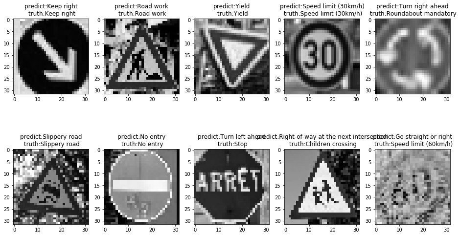

```python
# run the pre-trained model to predict
output, acc, loss, top_k = sess.run([model.output, model.accuracy, model.loss, model.top_k],
                                    feed_dict={model.x_placeholder:imgs_arr, model.y_placeholder:label_arr,
                                               model.keep_p:1.0})
print('the predict accuracy of web images is:', str(acc))

predict = np.argmax(output, 1)
plt.figure(figsize=(16, 9))
for i in range(len(imgs_arr)):
    plt.subplot(2, 5, i + 1)
    plt.title('predict:'+label_dict[str(int(predict[i]))]+'\n truth:'+label_dict[str(int(label_arr[i]))])
    plt.imshow(imgs_arr[i, :, :], cmap='gray')
plt.show()
```

### Output Top 5 Softmax Probabilities For Each Image Found on the Web

For each of the new images, print out the model's softmax probabilities to show the **certainty** of the model's predictions (limit the output to the top 5 probabilities for each image). [`tf.nn.top_k`](https://www.tensorflow.org/versions/r0.12/api_docs/python/nn.html#top_k) could prove helpful here.

The example below demonstrates how tf.nn.top_k can be used to find the top k predictions for each image.

`tf.nn.top_k` will return the values and indices (class ids) of the top k predictions. So if k=3, for each sign, it'll return the 3 largest probabilities (out of a possible 43) and the correspoding class ids.

Take this numpy array as an example. The values in the array represent predictions. The array contains softmax probabilities for five candidate images with six possible classes. `tf.nn.top_k` is used to choose the three classes with the highest probability:

```
# (5, 6) array
a = np.array([[ 0.24879643,  0.07032244,  0.12641572,  0.34763842,  0.07893497,
         0.12789202],
       [ 0.28086119,  0.27569815,  0.08594638,  0.0178669 ,  0.18063401,
         0.15899337],
       [ 0.26076848,  0.23664738,  0.08020603,  0.07001922,  0.1134371 ,
         0.23892179],
       [ 0.11943333,  0.29198961,  0.02605103,  0.26234032,  0.1351348 ,
         0.16505091],
       [ 0.09561176,  0.34396535,  0.0643941 ,  0.16240774,  0.24206137,
         0.09155967]])
```

Running it through `sess.run(tf.nn.top_k(tf.constant(a), k=3))` produces:

```
TopKV2(values=array([[ 0.34763842,  0.24879643,  0.12789202],
       [ 0.28086119,  0.27569815,  0.18063401],
       [ 0.26076848,  0.23892179,  0.23664738],
       [ 0.29198961,  0.26234032,  0.16505091],
       [ 0.34396535,  0.24206137,  0.16240774]]), indices=array([[3, 0, 5],
       [0, 1, 4],
       [0, 5, 1],
       [1, 3, 5],
       [1, 4, 3]], dtype=int32))
```

Looking just at the first row we get `[ 0.34763842, 0.24879643, 0.12789202]`, you can confirm these are the 3 largest probabilities in `a`. You'll also notice `[3, 0, 5]` are the corresponding indices.

```python
### Print out the top five softmax probabilities for the predictions on the German traffic sign images found on the web.
### Feel free to use as many code cells as needed.
print(top_k[0])
print(top_k[1])
```

```
[[  1.00000000e+00   1.06447605e-19   4.05146957e-20   4.74103778e-21
    1.87866530e-23]
 [  1.00000000e+00   7.37162864e-15   1.63145493e-21   6.15492629e-23
    5.56724132e-23]
 [  1.00000000e+00   4.69189401e-32   8.88218357e-38   0.00000000e+00
    0.00000000e+00]
 [  1.00000000e+00   1.64398304e-11   2.35198119e-13   4.66793957e-23
    3.07634107e-23]
 [  3.83373827e-01   1.56300962e-01   1.11141562e-01   8.24019611e-02
    6.80121854e-02]
 [  1.00000000e+00   4.58765070e-09   1.50478519e-10   3.26221689e-12
    1.66451293e-12]
 [  1.00000000e+00   1.31442593e-10   5.46305645e-17   2.76542291e-21
    2.44920667e-21]
 [  7.62751281e-01   8.67487341e-02   6.40631244e-02   3.11125182e-02
    2.25958340e-02]
 [  9.86572623e-01   1.06138643e-02   2.18002498e-03   2.88457784e-04
    2.83240195e-04]
 [  9.53132510e-01   1.69339385e-02   6.44845702e-03   6.18995447e-03
    5.28505724e-03]]
[[38 13  5  2 34]
 [25 22 20 29 13]
 [13 15 12  0  1]
 [ 1  2  0  5  4]
 [33 36 18 14  1]
 [23 29 31 20 19]
 [17 14 33 34  9]
 [34 14 36 35 25]
 [11 27 30 23 28]
 [36 18 20 25 35]]
```

### Project Writeup

Once you have completed the code implementation, document your results in a project writeup using this [template](https://github.com/udacity/CarND-Traffic-Sign-Classifier-Project/blob/master/writeup_template.md) as a guide. The writeup can be in a markdown or pdf file.

## Step 4 (Optional): Visualize the Neural Network's State with Test Images

Here I visualize the convolution and maxpool result.

```python
### Visualize your network's feature maps here.
### Feel free to use as many code cells as needed.

# image_input: the test image being fed into the network to produce the feature maps
# tf_activation: should be a tf variable name used during your training procedure that represents the calculated state of a specific weight layer
# activation_min/max: can be used to view the activation contrast in more detail, by default matplot sets min and max to the actual min and max values of the output
# plt_num: used to plot out multiple different weight feature map sets on the same block, just extend the plt number for each new feature map entry

def outputFeatureMap(image_input, sess, tf_activation, activation_min=-1, activation_max=-1 ,plt_num=1):
    # Here make sure to preprocess your image_input in a way your network expects
    # with size, normalization, ect if needed
    # image_input =
    # Note: x should be the same name as your network's tensorflow data placeholder variable
    # If you get an error tf_activation is not defined it may be having trouble accessing the variable from inside a function
    image_input = np.reshape(image_input, [1, 32, 32])
    activation = tf_activation.eval(session=sess, feed_dict={model.x_placeholder:image_input})
    print(activation.shape)
    featuremaps = activation.shape[3]
    plt.figure(plt_num, figsize=(14, 14))
    for featuremap in range(featuremaps):
        plt.subplot(5, 6, featuremap + 1) # sets the number of feature maps to show on each row and column
        plt.title('FeatureMap ' + str(featuremap)) # displays the feature map number
        if activation_min != -1 & activation_max != -1:
            plt.imshow(activation[0,:,:, featuremap], interpolation="nearest", vmin =activation_min, vmax=activation_max, cmap="gray")
        elif activation_max != -1:
            plt.imshow(activation[0,:,:, featuremap], interpolation="nearest", vmax=activation_max, cmap="gray")
        elif activation_min !=-1:
            plt.imshow(activation[0,:,:, featuremap], interpolation="nearest", vmin=activation_min, cmap="gray")
        else:
            plt.imshow(activation[0,:,:, featuremap], interpolation="nearest", cmap="gray")
    plt.show()
```

### After the first convolution map:

```
(1, 28, 28, 6)
```

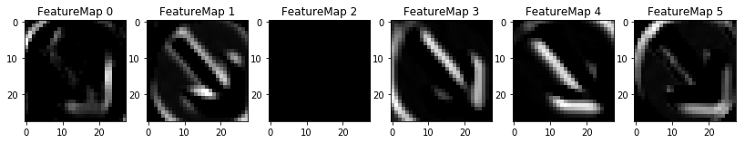

```python
outputFeatureMap(imgs_arr[0], sess, model.conv1)
```

### After the first maxpool

```
(1, 14, 14, 6)
```

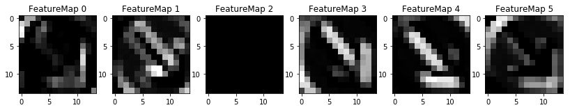

```python
outputFeatureMap(imgs_arr[0], sess, model.maxpool1)
```

### The second convolutional feature map result:

```
(1, 10, 10, 16)
```

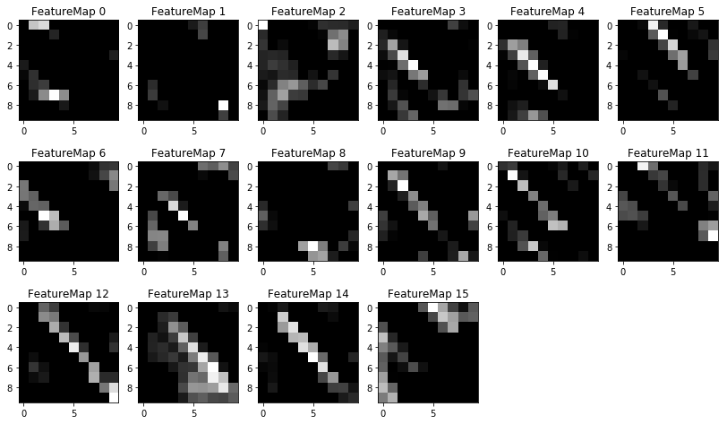

```python
outputFeatureMap(imgs_arr[0], sess, model.conv2)
```

### The Second maxpool

```
(1, 5, 5, 16)
```

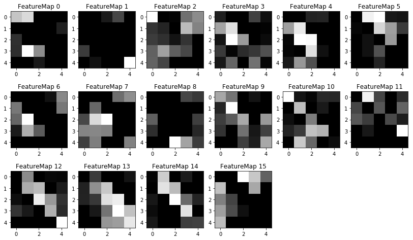

```python
outputFeatureMap(imgs_arr[0], sess, model.maxpool2)
```